# ECO 395M exercise 4

Phillip An, Paul Park, Min Jin Kang

2023-04-07

## Market segmentation

Method to be used is `K-means clustering`. With this method, we will be able to detect interesting market segments that seem to be exceptional within NutrientH20’s social-media audience.

Read the `social_marketing.csv` and let’s take a look for the 36 different categories

36 different categories of interest

| chatter | current_events | travel | photo_sharing | uncategorized | tv_film |
| --- | --- | --- | --- | --- | --- |
| sports_fandom | politics | food | family | home_and_garden | music |
| news | online_gaming | shopping | health_nutrition | college_uni | sports_playing |
| cooking | eco | computers | business | outdoors | crafts |
| automotive | art | religion | beauty | parenting | dating |
| school | personal_fitness | fashion | small_business | spam | adult |

With K-means clustering, we can cluster these categories, for example, “physical wellness” can be one cluster containing `personal_fitness`, `health_nutrition`, `outdoors`.

As mentioned in the question, we can check there are categories like `spam`, `adult`, `uncategorized`, and I will remove `spam` and `adult` to clean our dataset.

```r
# drop first column, which user has labeled as random 9-digit code
X=data[,-1]
# drop spam and adult column which slip through the data
X=X[,-(35:36)]
# center and scale
X=scale(X, center=TRUE, scale=TRUE)
# Extract the centers and scales from the rescaled data (which are named attributes)
mu = attr(X,"scaled:center")
sigma = attr(X,"scaled:scale")
```

After cleaning/centering/scaling the data, I will start with correlation plot for k-means clustering, as correlation plot can visualize which categories in the dataset are strongly correlated each other, and also can identify which categories have similar scales.

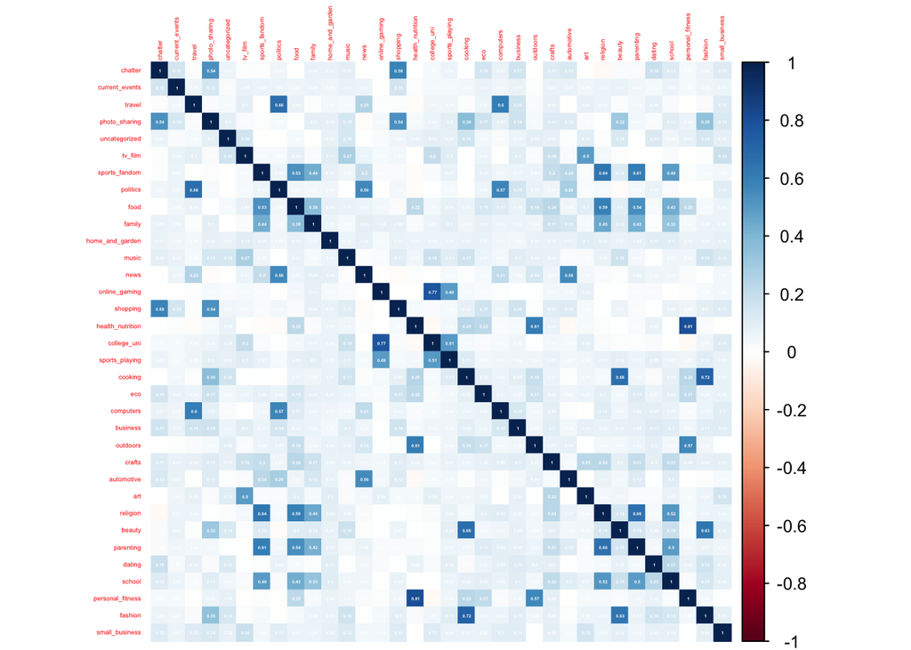

As there’s so many variables, I will sort highest correlations.

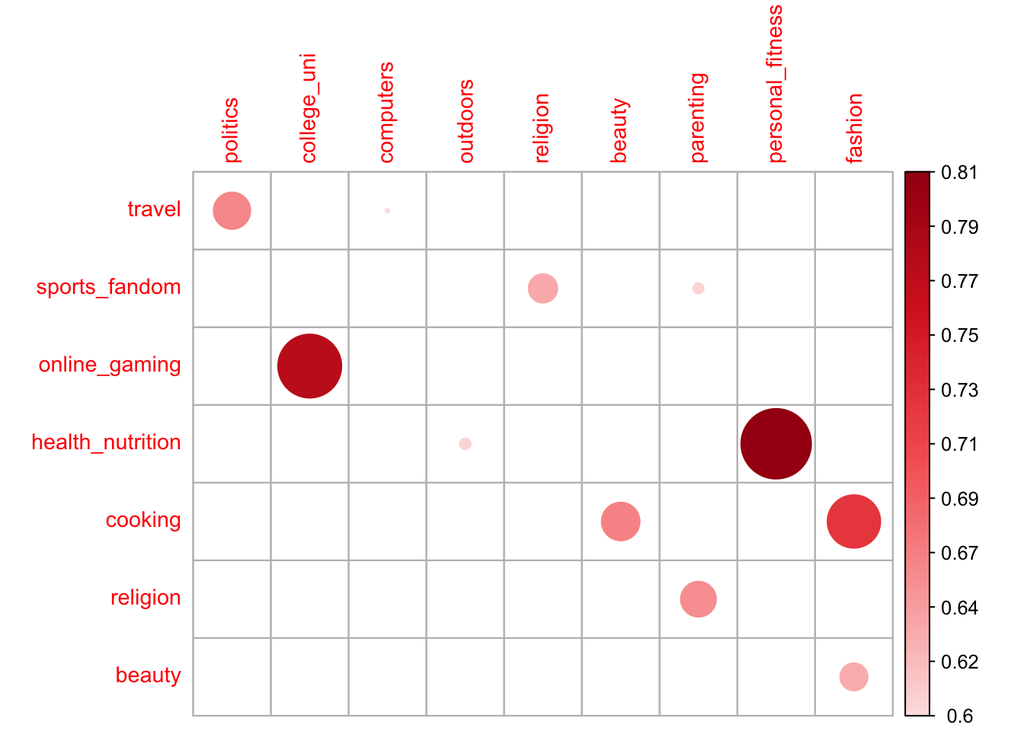

Highest correlation among categories

| Var1 | Var2 | Freq |
| --- | --- | --- |
| health_nutrition | personal_fitness | 0.8099024 |
| online_gaming | college_uni | 0.7728393 |
| cooking | fashion | 0.7214027 |
| cooking | beauty | 0.6642389 |
| travel | politics | 0.6602100 |
| religion | parenting | 0.6555973 |
| sports_fandom | religion | 0.6379748 |
| beauty | fashion | 0.6349739 |
| health_nutrition | outdoors | 0.6082254 |
| sports_fandom | parenting | 0.6077181 |
| travel | computers | 0.6029349 |

As you can see, `health_nutrition` and `personal_fitness` has the highest correlation and this is exactly what I thought would be in the same cluster - “physical wellness”.

We’ve finished previewing for k-means clustering with correlation plot, and we’ll start analyzing with k-means clustering.

### K-means clustering

First, will start from choosing optimal K, the amount of clusters. Below is Elbow plot. Elbow plot used to determine the optimal number of clustering. The plot displays within-cluster sum of squares(WSS) as a function of the number of clusters.

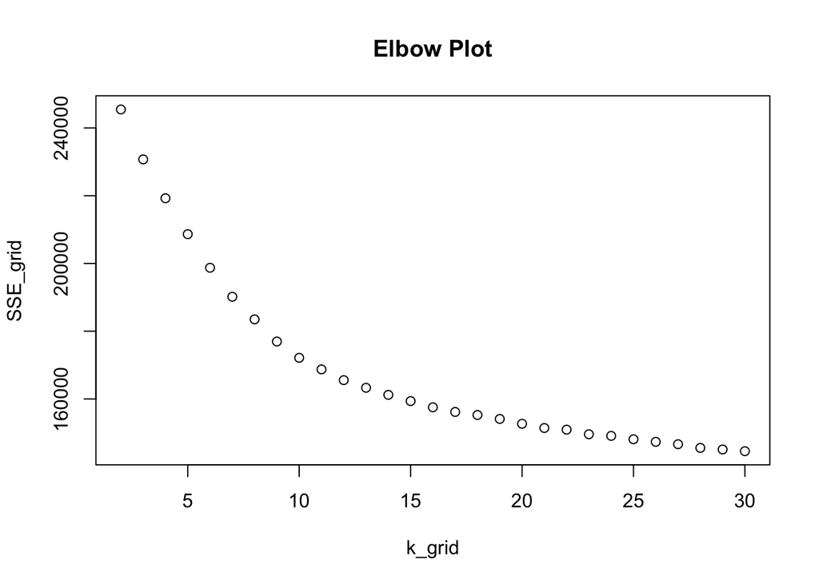

10 seems to me to be the elbow point, so we’ll use 10 for k.

We can get surface-level information about market segments for NutrientH20.

|  | cluster1 |
| --- | --- |
| college_uni | 11.098870 |
| online_gaming | 10.850283 |
| chatter | 4.096045 |
| sports_playing | 2.745763 |
| photo_sharing | 2.655367 |

|  | cluster2 |
| --- | --- |
| cooking | 11.788009 |
| photo_sharing | 6.083512 |
| fashion | 5.995717 |
| beauty | 4.218415 |
| chatter | 4.194861 |

|  | cluster3 |
| --- | --- |
| news | 6.798122 |
| politics | 5.509390 |
| automotive | 4.377934 |
| chatter | 4.124413 |
| sports_fandom | 3.046948 |

|  | cluster4 |
| --- | --- |
| tv_film | 5.597087 |
| art | 5.038835 |
| chatter | 3.929612 |
| college_uni | 2.548544 |
| photo_sharing | 2.453883 |

|  | cluster5 |
| --- | --- |
| dating | 9.323077 |
| chatter | 7.948718 |
| photo_sharing | 2.630769 |
| fashion | 2.512821 |
| school | 2.266667 |

|  | cluster6 |
| --- | --- |
| chatter | 9.731328 |
| photo_sharing | 5.963693 |
| shopping | 4.120332 |
| current_events | 1.992739 |
| health_nutrition | 1.600622 |

|  | cluster7 |
| --- | --- |
| politics | 11.267241 |
| travel | 9.103448 |
| computers | 4.100575 |
| chatter | 4.060345 |
| news | 3.617816 |

|  | cluster8 |
| --- | --- |
| sports_fandom | 6.186930 |
| religion | 5.539514 |
| food | 4.724924 |
| parenting | 4.246201 |
| chatter | 3.854103 |

|  | cluster9 |
| --- | --- |
| chatter | 3.076317 |
| photo_sharing | 1.547547 |
| current_events | 1.264385 |
| health_nutrition | 1.143247 |
| travel | 1.085706 |

|  | cluster10 |
| --- | --- |
| health_nutrition | 12.591270 |
| personal_fitness | 6.661376 |
| chatter | 3.767196 |
| cooking | 3.414021 |
| outdoors | 2.903439 |